# Prison/Jail Population per country/state

### Introduction

**An introduction of the problem domain and a description of the variable(s) you are choosing to analyze (and why!)**

Prison and jail incarceration trend is always the controversial topic that has aroused the world’s attention and elicited passionate discussion. The racial categories, including AAPI, Black, Latinx, Native, and White Americans, would be a breakthrough point for understanding the potential disparities within the criminal justice system. I choose to focus on the total prison population of both Black and White American prisons per county/state starting in 1970. I am committed to figuring out which group is more likely to be incarcerated and checking out whether unconscious racial discrimination existed.

### Summary Information

**Considered questions:** > How many total Black prisons have there been in the U.S. by 2010? > How many total White prisons have there been in the U.S. by 2010? > How much has the total Black prisons change between 2010 and 30 years before that? > How much has the total White prisons change between 2010 and 30 years before that? > Which state has had the highest number of Black prisons in 2010?

```
##   total_black_prison_pop
## 1                  47675
```

```
##   total_white_prison_pop
## 1                 448158
```

```
## [1] "CA"
```

```
##   previous_black_prison
## 1                  6393
```

```
##   total_black_prison_pop
## 1                  41282
```

```
##   previous_white_prison
## 1                  4243
```

```
##   total_white_prison_pop
## 1                 443915
```

```
## [1] 153811
```

```
## [1] 36
```

### The Dataset

**Who collected the data?**

The dataset collected and released by Vera Institute of Justice.

**How was the data collected or generated?**

The dataset assembled the information from the U.S. Department of Justice Bureau of Justice Statistics(BJS) and supplemented it with state departments of correction.

**Why was the data collected?**

The main purpose of the data collection is to provide county-level information on prison and jail incarceration and other related measures over time for the entire United States.

**How many features (columns) are in the data?**

There are 36 features in the data.

**What, if any, ethical questions or questions of power do you need to consider when working with this data?**

Considering the data included a large size of statistics, widespread in public; and its classification related to the different racial backgrounds, the ethical question we might need to consider is whether any external factors would affect the accuracy of the data withheld. For example, data collectors and contributors hold their subjective perspectives on some specific groups, causing race-related biases in analyzing the incarceration trend.

**What are possible limitations or problems with this data? (at least 200 words)**

The dataset includes information on the total population of prisons in every single county and state of the U.S., crossed through a long time span. Therefore, huge amounts of data are required to be organized and summarized, where we need to choose the most representative features to support the different racial backgrounds. Besides, we should carefully remove the “NA” values from the analyzing, avoided them to cause the inaccuracy and misunderstanding.

### Trends Over Time Chart

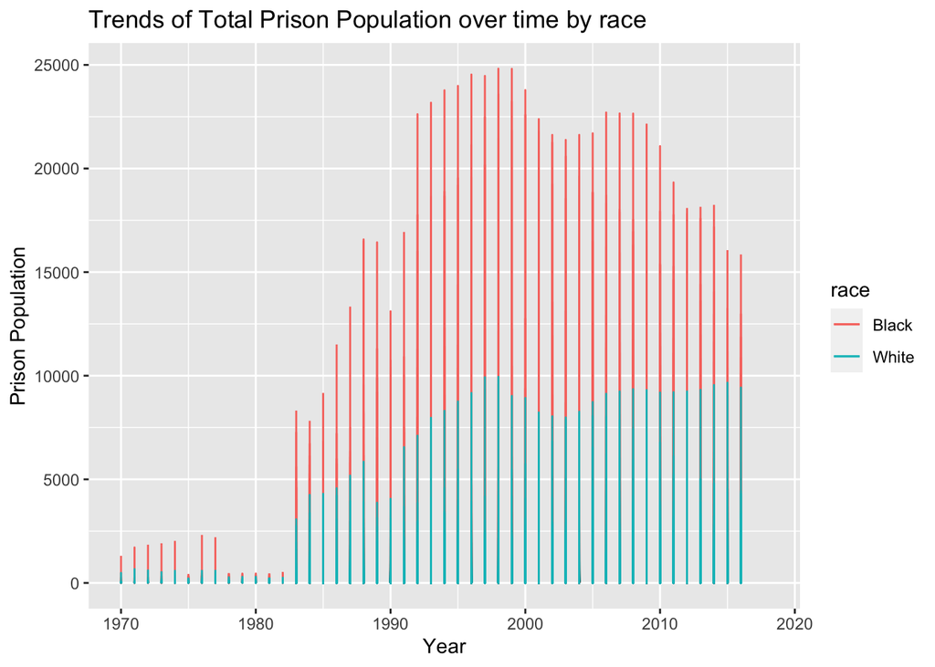

The chart significantly displays the total population of black and white prisons over the time in U.S. It proves that the number of black prison is much more greater than the number of white prison. The total prison population starts to increase from 1980 and finally reaches to the peak between 1990 and 2000 with the majority number of black prison.

### Variable Comparison Chart

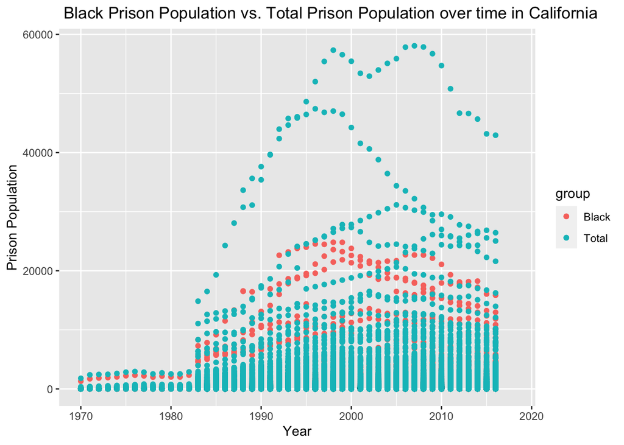

The scatterplot shows the comparison between the black prison population and the total prison population in California, committed to seeing how the prison population changes over time; and what role the black prison population stands for in general. The conclusion I would make is that the prison population has always been fluctuating, tending to have increased trends as time passed by. Among the total prison population, the number of black prisons would play a crucial role since it has occupied around half of the overall prison number in the year between 1990 and 2000.

### Map

[output not shown]

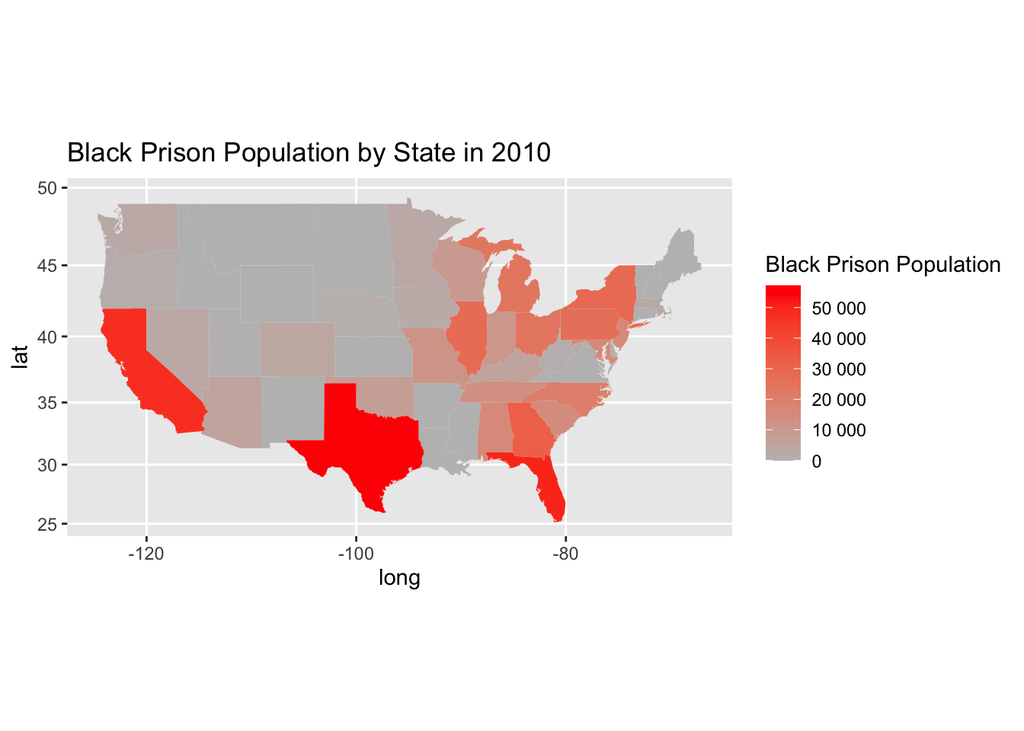

Based on the given map, it is obvious to see that both Texas and California states have the greater number of black prison in the year of 2010. At the same time, many of the states in the east coast has relatively small amount of the black prison population. The geographical map gives an overall insight about the population comparison between each states across the whole country.